# Relationship Between COVID-19 Cases and the Youth Population (by County)

### Yash Kapoor

COVID-19 is a contagious desease caused by a coronavirus called SARS-CoV-2. It is believed to have originated in Wuhan, China, at the Huanan seafood market, but tracing the origin has proven to be quite difficult.

COVID-19 is thought to spread mainly through close contact from person to person, including between people who are physically near each other (within about 6 feet). People who are infected but do not show symptoms can also spread the virus to others. Older adults and people who have severe underlying medical conditions like heart or lung disease or diabetes seem to be at higher risk for developing more serious complications from COVID-19 illness.

Cases of reinfection with COVID-19 have been reported but are rare. As of December 2020, we are still learning about how the virus spreads and the severity of illness it causes.

A few of the most common symptoms of COVID-19 are

- Fever or chills
- Cough
- Shortness of breath or difficulty breathing
- Fatigue
- Muscle or body aches
- Headache
- New loss of taste or smell
- Sore throat
- Congestion or runny nose
- Nausea or vomiting
- Diarrhea

More information about the virus can be found at [the CDC website](https://www.cdc.gov/coronavirus/2019-ncov/your-health/index.html), as well as [the WHO website](https://www.who.int/emergencies/diseases/novel-coronavirus-2019). Many countries have their own dashboards set up to accurately track and document COVID-19 cases.

On March 11, 2020, the World Health Organization (WHO) announced the coronavirus outbreak a global pandemic.

### About this analysis:

Since older adults are believed to be at higher risk of being infected by COVID-19, there were cases throughout the world where youths - many of them high school or college students - (inaccurately) believed that they were immune to COVID and completely disregarded safety guidelines (wearing masks, staying 6 feet away from other people, using hand sanitizer, etc.) and were involved in mass gatherings (partying, bars, crowded restaurants).

Older adults being at *higher* risk does not imply that young adults aren't at risk. They might be slightly more immune, but that makes them the perfect carrier since carriers do not display symptoms.

This analysis will try to investigate if there is a relationship between the number of COVID-19 cases and the youth population of a county. Throughout this analysis, "youth population" refers to young adults of ages 15 to 24. We will only be looking at the data for the United States in this analysis.

First of all, we will include some libraries for our analysis.

```python
# for handling data
import pandas as pd
import numpy as np

# for plotting data
import matplotlib.pyplot as plt
import seaborn as sns

# for data collection
import requests
import bs4

# for machine learning
from sklearn.linear_model import LinearRegression
```

## Data Collection

The first step of our analysis is gathering the data.

There are 2 kinds of data that we need to collect: data about the youth populations of each county of each state, and data about the number of cases over time for each county in each state.

The data about the populations will be extracted from the [website](https://ojjdp.ojp.gov/) of The Office of Juvenile Justice and Delinquency Prevention (OJJDP). As a federal office, the data from OJJDP is of course reliable, which is why we can use this data.

The data about number of cases over time, by county, will be extracted from the New York Times [GitHub repository](https://github.com/nytimes/covid-19-data) that houses COVID-19 data on not just county level, but also state and national levels. As one of the most popular news websites in the United States, the New York Times been known to achieve 70 million unique monthly visitors, outperforming other news channels like NBC News and The Washington Post. This gives us assurance about the accuracy and credibility of the data.

First we will extract the cases by county over time data.

We will only be reading the first 784,209 rows since they contain data up to November 30, 2020, which is enough for our purposes since we are examining past trends. If they choose to do so, anyone following this tutorial can remove the "nrows" argument to read all the available rows.

Some people might not be familiar with the FIPS column in the data, but it is just a "fancy" identifier for counties, and more accurate than ZIP codes in defining the boundaries of a county.

```python
# Using Pandas' read_csv() function to directly read the CSV file from the repository
cases_data_url = "https://raw.githubusercontent.com/nytimes/covid-19-data/master/us-counties.csv"
cases_data = pd.read_csv(cases_data_url, nrows=784209)
cases_data
```

|  | date | county | state | fips | cases | deaths |
| --- | --- | --- | --- | --- | --- | --- |
| 0 | 2020-01-21 | Snohomish | Washington | 53061.0 | 1 | 0.0 |
| 1 | 2020-01-22 | Snohomish | Washington | 53061.0 | 1 | 0.0 |
| 2 | 2020-01-23 | Snohomish | Washington | 53061.0 | 1 | 0.0 |
| 3 | 2020-01-24 | Cook | Illinois | 17031.0 | 1 | 0.0 |
| 4 | 2020-01-24 | Snohomish | Washington | 53061.0 | 1 | 0.0 |
| ... | ... | ... | ... | ... | ... | ... |
| 784204 | 2020-11-30 | Sublette | Wyoming | 56035.0 | 430 | 1.0 |
| 784205 | 2020-11-30 | Sweetwater | Wyoming | 56037.0 | 1888 | 6.0 |
| 784206 | 2020-11-30 | Teton | Wyoming | 56039.0 | 1644 | 2.0 |
| 784207 | 2020-11-30 | Uinta | Wyoming | 56041.0 | 1070 | 4.0 |
| 784208 | 2020-11-30 | Washakie | Wyoming | 56043.0 | 440 | 8.0 |

784209 rows × 6 columns

```python
# taking a look at the column data types and null values that Pandas can identify,
#   we see that the number of non-null values in the 'fips' and 'deaths' columns
#   doesn't match the number of rows, but that is fine since we'll be dropping
#   those 2 columns
cases_data.info()
```

```
<class 'pandas.core.frame.DataFrame'>
RangeIndex: 784209 entries, 0 to 784208
Data columns (total 6 columns):
 #   Column  Non-Null Count   Dtype
---  ------  --------------   -----
 0   date    784209 non-null  object
 1   county  784209 non-null  object
 2   state   784209 non-null  object
 3   fips    776760 non-null  float64
 4   cases   784209 non-null  int64
 5   deaths  767866 non-null  float64
dtypes: float64(2), int64(1), object(3)
memory usage: 35.9+ MB
```

Next, we will look at the data for the youth populations for each county. The most recent data available is from 2019, which is what we'll be utilizing for our analysis.

This data is slightly more troublesome to extract because we need to extract the data for each state individually and then combine them together to get a dataset that we can work with.

To get the data for each state, we'll first need to submit a GET request to the OJJDP website, extract the table from within the HTML and then convert the table to a Pandas DataFrame.

```python
# We first create a base_url and a params variable,
# base_url: url that we'll be scraping data from
# params: the query string key-value pairs that will specify the state, year and age ranges
# we'll be changing the 'selState' property to specify the state
base_url = "https://www.ojjdp.gov/ojstatbb/ezapop/asp/comparison_display.asp"
params = {
    "display_type" : "counts",
    "export_file" : "",
    "printer_friendly" : "",
    "selState" : 1,
    "col_var" : "v01",
    "submit" : "SHOW TABLE",
    "v0130" : "v0130",
    "selLowerYear" : 1,
    "selUpperYear" : 1,
    "v0516" : "v0516",
    "v0519" : "v0519",
    "v0517" : "v0517",
    "v0520" : "v0520",
    "v0518" : "v0518",
    "selLowerAge" : 1,
    "selUpperAge" : 1
}

# the states are mapped to their FIPS values, and some FIPS values don't have
# corresponding states, so we'll be skipping over those values
not_working_indices = [3,7,14,43,52]
sel_state_working_indices = [x for x in range(1,57) if x not in not_working_indices]
```

In the cell above, we set the basic values that we'll need to be able to create our dataframe.

The cell below is where we do all the work to create the individual dataframes and combining them.

Note that the below piece of code is doing a lot of things:

- retrieving HTML from 51 different webpages
- parsing them using a library to allow for easier and faster information retrieval
- essentially converting an HTML table into a Python list
- creating a dataframe out of said list
- combining 51 such dataframes into a single dataframe that we can work with

Due to all the things that have to be done, this piece of code will not be able to execute instantaneously and can take up to a full minute to run (depending on the strength of your internet connection). While waiting for this to run, please do not kill the process when there is no visible output within a few seconds.

```python
# we'll create a dataframe for each state and store it in a list, then combine the
# dataframes into a single dataframe at the end
df_list = [0]*51
j = 0
for i in sel_state_working_indices:
    params['selState'] = i     # changing the 'selState' property to specify the state
    r = requests.get(base_url, params=params)    # making the GET request
    soup = bs4.BeautifulSoup(r.text, 'html.parser')    # using BeautifulSoup to parse the HTML to make lookup easier
    txt = soup.find(id="tbldata").text  # finding the table, in HTML, that we want to scrape, and returning it as plain text
    # modifying the plain text so we can more easily extract relevant information from it
    txt = txt.replace("\n"," ")
    txt = ([x.strip() for x in txt.split("\r") if x.strip() != ''])
    txt[0] = 'County'
    txt[1] = '2019'
    txt.insert(2,'Total')
    txt.insert(3,'All Counties')
    county_names = [x for i,x in enumerate(txt) if (i) % 3 == 0][1:]
    pop_2019 = [x for i,x in enumerate(txt) if (i+1) % 3 == 0][1:]
    # creating the dataframe for this particular state
    df = pd.DataFrame(list(zip(county_names,pop_2019)),columns=['County Name', 'Youth Population in 2019'])
    state_name = soup.find('h2').text.split(" ")[-1]   # extracting the state name from the webpage
    df['State'] = state_name  # creating a new column in the dataframe and setting every value equal to the state name
    df_list[j] = df   # adding the newely created dataframe to the list of dataframes
    j = j+1    # incrementing the dataframe list index

# combining all the dataframes into a single dataframe and resetting the index
youth_pop_all_states = pd.concat(df_list)
youth_pop_all_states.reset_index(drop=True)
```

|  | County Name | Youth Population in 2019 | State |
| --- | --- | --- | --- |
| 0 | All Counties | 635,707 | Alabama |
| 1 | Autauga County | 6,837 | Alabama |
| 2 | Baldwin County | 24,175 | Alabama |
| 3 | Barbour County | 2,889 | Alabama |
| 4 | Bibb County | 2,612 | Alabama |
| ... | ... | ... | ... |
| 3187 | Sweetwater County | 5,380 | Wyoming |
| 3188 | Teton County | 2,304 | Wyoming |
| 3189 | Uinta County | 2,458 | Wyoming |
| 3190 | Washakie County | 903 | Wyoming |
| 3191 | Weston County | 683 | Wyoming |

3192 rows × 3 columns

## Data Processing

After we have collected the data we require into DataFrames that we can work with, we need to process this data so it can better serve our purposes.

First we'll work with the cases by county over time dataframe. There are a few things we need to do here:

- First we'll parse the 'date' column as dates, i.e. we'll convert them to a datetime format that Python and Pandas understands
- We can then remove the 'day' part of the date and leave just the month, which will allow us to group by month then state and county so we can look at the number of cases/deaths per county per state as a function of time in months
- We also need to realize that the data in this dataframe is cumulative (this is mentioned in the README on the GitHub repository), i.e. for a given date and location (by state and county), the number of COVID cases up to that point is stored in the cases column of the row. This means that we can represent each entire month by just looking at the last day.
- We could also just directly do a group by on the state and county and look at a graph of total COVID cases vs. youth population (including both state and county is necessary to uniquely identify the county since multiple states can have counties with the same names).

```python
# cleaning the cases by county over time data

# converting the 'date' column from type 'object' to type 'datetime'
# then extracting the month from it and storing it as a separate column
# in this case, we're looking at the data for 2020 only so extracting the year isn't
#   necessary, which is why I'm discarding it
# after doing that, I selected only the columns I require for my analysis and then
#   changed the index to a double level index with year and month. as I stated above,
#   this will help us in performing groupby-aggregate operations on the data

# as stated above, we can represent the number of cases at the end of the month
#   by simply looking at the data for the last day of each month
#   to accomplish this, we can create a datetime index and index our
#   dataframe using it

cases_data['date'] = pd.to_datetime(cases_data['date'])
cases_data['month'] = pd.DatetimeIndex(cases_data['date']).month
dates = pd.date_range(start='2020-01-31',end='2020-11-30',freq='M')
cases_data = cases_data[[x in dates for x in cases_data['date']]]
cases_data = cases_data.loc[:, ['month','state','county','cases']]
cases_data.head(10)
```

|  | month | state | county | cases |
| --- | --- | --- | --- | --- |
| 33 | 1 | Arizona | Maricopa | 1 |
| 34 | 1 | California | Los Angeles | 1 |
| 35 | 1 | California | Orange | 1 |
| 36 | 1 | California | Santa Clara | 1 |
| 37 | 1 | Illinois | Cook | 2 |
| 38 | 1 | Washington | Snohomish | 1 |
| 376 | 2 | Arizona | Maricopa | 1 |
| 377 | 2 | California | Humboldt | 1 |
| 378 | 2 | California | Los Angeles | 1 |
| 379 | 2 | California | Marin | 1 |

```python
# At first glance, that data looks fine, but a closer inspection will reveal that there
# are many counties with county name 'Unknown'
cases_data[cases_data['county'] == 'Unknown']
```

|  | month | state | county | cases |
| --- | --- | --- | --- | --- |
| 21805 | 3 | Arizona | Unknown | 0 |
| 21857 | 3 | Arkansas | Unknown | 5 |
| 21959 | 3 | Colorado | Unknown | 129 |
| 21970 | 3 | Connecticut | Unknown | 77 |
| 22156 | 3 | Georgia | Unknown | 182 |
| ... | ... | ... | ... | ... |
| 783375 | 11 | Rhode Island | Unknown | 10879 |
| 783576 | 11 | Tennessee | Unknown | 1108 |
| 783863 | 11 | Utah | Unknown | 185 |
| 783880 | 11 | Vermont | Unknown | 8 |
| 784054 | 11 | Washington | Unknown | 2 |

237 rows × 4 columns

```python
# Summing up the number of cases in all the unknown counties at the end of November, and
#   dividing by the total number of cases in November, we see that the unknown counties
#   account for about 0.35% of the total number of cases, so leaving this data out of
#   our calculations shouldn't affect any trends
# Note that we only needed to look at the data for November since the data is cumulative
#   If the total count for each month was initialized to 0 then we would need to sum up
#   the values for each county at the end of each month instead of just looking at the
#   data for November
unknown_sum = cases_data.loc[cases_data['month'] == 11,:].loc[cases_data['county'] == 'Unknown',:][['cases']].sum()
total_sum = cases_data.loc[cases_data['month'] == 11,:][['cases']].sum()
print(unknown_sum)
print(total_sum)
print(unknown_sum/total_sum)
```

```
cases    48864
dtype: int64
cases    13614732
dtype: int64
cases    0.003589
dtype: float64
```

```python
# since the number of COVID cases for the datapoints with 'county' = 'Unknown'
#   are only a very small fraction of the entire dataset, we can drop those
#   points without any loss of information
cases_data = cases_data[cases_data['county'] != 'Unknown']
cases_data = cases_data.reset_index(drop=True).sort_values('month')
cases_data
```

|  | month | state | county | cases |
| --- | --- | --- | --- | --- |
| 0 | 1 | Arizona | Maricopa | 1 |
| 1 | 1 | California | Los Angeles | 1 |
| 2 | 1 | California | Orange | 1 |
| 3 | 1 | California | Santa Clara | 1 |
| 4 | 1 | Illinois | Cook | 2 |
| ... | ... | ... | ... | ... |
| 25056 | 11 | Kentucky | Monroe | 706 |
| 25057 | 11 | Kentucky | Montgomery | 911 |
| 25058 | 11 | Kentucky | Morgan | 332 |
| 25048 | 11 | Kentucky | Mason | 456 |
| 27199 | 11 | Wyoming | Washakie | 440 |

27200 rows × 4 columns

```python
# in the above output, we see that the 'county' column of the dataframe only has the county name,
#   without the 'County' at the end
# to ensure that the county names from both dataframes match, we can easily add a ' County' at
#   the end of every county name due to the properties of Series and dataframes
# note that we could've opted to remove the 'County' from the end of the county names from the
#   other dataframe as well, and it would produce equivalent results, but it would've been
#   slightly more complicated, which is why we're going with this method

cases_data['county'] = cases_data['county'] + ' County'

cases_data
```

|  | month | state | county | cases |
| --- | --- | --- | --- | --- |
| 0 | 1 | Arizona | Maricopa County | 1 |
| 1 | 1 | California | Los Angeles County | 1 |
| 2 | 1 | California | Orange County | 1 |
| 3 | 1 | California | Santa Clara County | 1 |
| 4 | 1 | Illinois | Cook County | 2 |
| ... | ... | ... | ... | ... |
| 25056 | 11 | Kentucky | Monroe County | 706 |
| 25057 | 11 | Kentucky | Montgomery County | 911 |
| 25058 | 11 | Kentucky | Morgan County | 332 |
| 25048 | 11 | Kentucky | Mason County | 456 |
| 27199 | 11 | Wyoming | Washakie County | 440 |

27200 rows × 4 columns

Since we have processed the cases data, now it is time to look at the youth population by county data.

Since this DataFrame wasn't a readymade product but is something we constructed from scratch using data scraped from the web in the Data Collection phase, it already doesn't have much (any?) superfluous information.

First thing we'll do is rename the columns so they match the column names of the cases dataframe exactly. This will help us when we try to combine the dataframes so we can have all the data together in a single dataframe. Perhaps the only other thing we can change now would be converting the youth population column to integer type from the object type, and we'd basically be done with processing this dataframe.

```python
# renaming the columns
youth_pop_all_states.columns = ['county', 'youth_pop_2019', 'state']

# converting the population column to integer type
# need to first remove all commas since Python cann't parse commas as part of an integer
youth_pop_all_states['youth_pop_2019'] = youth_pop_all_states['youth_pop_2019'].str.replace(',','').astype('int32')
youth_pop_all_states.info()
youth_pop_all_states
```

```
<class 'pandas.core.frame.DataFrame'>
Int64Index: 3192 entries, 0 to 23
Data columns (total 3 columns):
 #   Column          Non-Null Count  Dtype
---  ------          --------------  -----
 0   county          3192 non-null   object
 1   youth_pop_2019  3192 non-null   int32
 2   state           3192 non-null   object
dtypes: int32(1), object(2)
memory usage: 87.3+ KB
```

|  | county | youth_pop_2019 | state |
| --- | --- | --- | --- |
| 0 | All Counties | 635707 | Alabama |
| 1 | Autauga County | 6837 | Alabama |
| 2 | Baldwin County | 24175 | Alabama |
| 3 | Barbour County | 2889 | Alabama |
| 4 | Bibb County | 2612 | Alabama |
| ... | ... | ... | ... |
| 19 | Sweetwater County | 5380 | Wyoming |
| 20 | Teton County | 2304 | Wyoming |
| 21 | Uinta County | 2458 | Wyoming |
| 22 | Washakie County | 903 | Wyoming |
| 23 | Weston County | 683 | Wyoming |

3192 rows × 3 columns

Now that we are done with each of the DataFrames individually, it is time to combine them together into a single DataFrame that we'll call 'data_df'. We will be joining the cases and youth population datasets on the state and county columns. It is precisely for this step that we renamed the columns of the youth population dataframe.

This new DataFrame will have the columns 'county', 'state', 'youth_pop_2019', 'cases' and 'month'.

It may seem odd to include month in this analysis. After all, we're trying to see if a relationship exists between the youth population and the number of COVID cases in a county. We're including month as a parameter so we can utilize our data better and observe trends over time. After all, making any conclusions based on data for any single month would not be very credible.

First we'll reset the indices since any duplicate indices can cause trouble while merging the dataframes.

Then we'll do the merge on the 'state' and 'county' columns.

Note that this is an inner join which discards the rows where there is no match.

While this will result in a loss of some information, at the moment we have no way of filling in any gaps or making reasonable assumptions about the values.

If we had to make any assumptions, we could say that for the counties that are in the youth populations dataframe but not in the cases dataframe don't have a non-negligible number of COVID cases; in which case, dropping them won't result in any significant loss of information.

Note that since the data for both datasets originated from different sources, it is very possible that there were some county names that either had typos in one of the datasets or were recorded with slight differences for some reason. Our code isn't powerful enough to test for, detect and correct such subtleties so we have no choice but to leave those differences alone and just drop those rows.

```python
cases_data.reset_index(drop=True, inplace=True)
youth_pop_all_states.reset_index(drop=True, inplace=True)
data_df = pd.merge(left=cases_data,right=youth_pop_all_states,left_on=['state','county'],\
                   right_on=['state','county'],how='inner')
data_df
```

|  | month | state | county | cases | youth_pop_2019 |
| --- | --- | --- | --- | --- | --- |
| 0 | 1 | Arizona | Maricopa County | 1 | 596324 |
| 1 | 2 | Arizona | Maricopa County | 1 | 596324 |
| 2 | 3 | Arizona | Maricopa County | 791 | 596324 |
| 3 | 4 | Arizona | Maricopa County | 3972 | 596324 |
| 4 | 5 | Arizona | Maricopa County | 9815 | 596324 |
| ... | ... | ... | ... | ... | ... |
| 21496 | 11 | Nebraska | Hayes County | 43 | 88 |
| 21497 | 10 | Texas | King County | 1 | 22 |
| 21498 | 11 | Texas | King County | 2 | 22 |
| 21499 | 11 | Nevada | Esmeralda County | 9 | 50 |
| 21500 | 11 | Texas | Loving County | 1 | 23 |

21501 rows × 5 columns

## Data visualization

Now that we finally have all our data in a single dataframe, we can start visualizing some information to gain some insight into the relationships between the data and whether or not we can spot any trends.

That being said, since our data collection and processing stages were so thorough, we're currently only looking at a single dataframe with just the attributes we need. This means that we don't have to deal with any unnecessary or superfluous information and will only have to make a few plots to observe the distribution and trends of the data. Due to this, our visualization stage will be relatively short and we'll move on to the next phase - machine learning, hypothesis testing and analysis - relatively soon.

It might be helpful to get an overall idea of the data we're dealing with first.

First of all, we can completely disregard the 'month' column in the table below since looking at the distribution of the months doesn't give us any information.

The other 2 columns are quite interesting though:

- in the 'cases' column, we see that although the maximum number of cases in a county is really high, that is clearly an outlier, since even the 75% is only 803; this tells us that for the most part, counties have cases ranging in the low 100s
- the youth population column is simimlar in that although the maximum is very high, it is very far removed from the data since even the 75% is orders of magnitude smaller
- we aren't paying too much attention to the averages since they have clearly been pulled up a significant amount by the outlier maxima

```python
data_df.describe()
```

|  | month | cases | youth_pop_2019 |
| --- | --- | --- | --- |
| count | 21501.000000 | 21501.000000 | 2.150100e+04 |
| mean | 7.197712 | 1645.327287 | 1.467234e+04 |
| std | 2.512763 | 8458.731547 | 4.963322e+04 |
| min | 1.000000 | 1.000000 | 2.200000e+01 |
| 25% | 5.000000 | 29.000000 | 1.394000e+03 |
| 50% | 7.000000 | 182.000000 | 3.206000e+03 |
| 75% | 9.000000 | 803.000000 | 9.001000e+03 |
| max | 11.000000 | 401034.000000 | 1.295905e+06 |

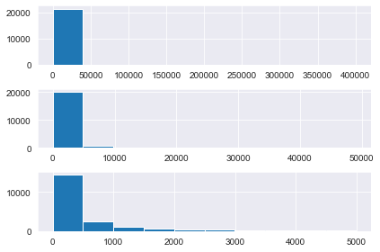

```python
# getting an idea of the COVID cases distribution in the country

fig, axs = plt.subplots(nrows=3,ncols=1)

# making a histogram we see that almost all counties have less than 50000 cases
data_df['cases'].hist(ax=axs[0])

# in that case, we can try to get a bettwe idea of the distribution within
#   that 0 to 50000 range by slicing the dataframe
data_df[data_df['cases'] < 50000]['cases'].hist(ax=axs[1])

# again we see that the vast majority of counties have between 0 and 5000
#   cases so we can apply the same technique once again
data_df[data_df['cases'] < 5000]['cases'].hist(ax=axs[2])

fig.tight_layout()
```

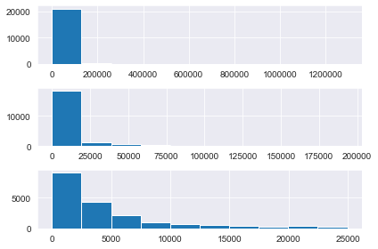

```python
# getting an idea of the youth population distribution in the country

fig, axs = plt.subplots(nrows=3,ncols=1)

# making a histogram we see that almost all counties have less than 50000 cases
data_df['youth_pop_2019'].hist(ax=axs[0])

# in that case, we can try to get a bettwe idea of the distribution within
#   that 0 to 50000 range by slicing the dataframe
data_df[data_df['youth_pop_2019'] < 200000]['youth_pop_2019'].hist(ax=axs[1])

# again we see that the vast majority of counties have between 0 and 5000
#   cases so we can apply the same technique once again
data_df[data_df['youth_pop_2019'] < 25000]['youth_pop_2019'].hist(ax=axs[2])

fig.tight_layout()
```

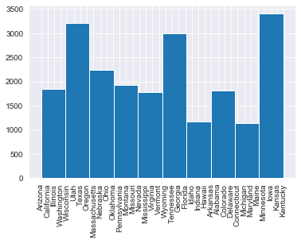

```python
# getting an idea of how many counties are in each state
data_df['state'].hist(xrot=90)
```

Plotting the data, it looks like there is indeed a correlation between youth population and number of COVID cases.

Note that here we use 2 different techniques for plotting the data since each has their own advantages:

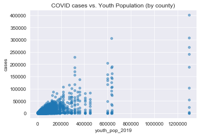

```python
data_df.plot(x='youth_pop_2019', y='cases', kind='scatter', alpha=0.5)
plt.title('COVID cases vs. Youth Population (by county)')
```

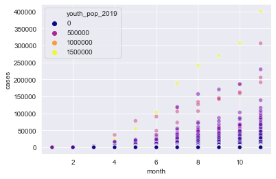

```python
# we can also create a cases vs. month scatterplot, with the youth population
#   modifying the hue of a point
# based on just the few plots we've made, we're already starting to see a
#   relationship between youth population and covid cases

sns.set_style("darkgrid")
sns.scatterplot(x='month', y='cases', hue='youth_pop_2019', palette='plasma', data=data_df, alpha=0.5)
```

## Model: Analysis, Hypothesis Testing and Machine Learning

Now that we have some idea about the data we're working with, it is time to apply machine learning and statistics in order to get concrete numbers about the relationships between attributes and uncover trends in the data.

We'll be using linear regression to obtain a predictive model of the data, which can be used for extrapolation.

As a quick reminder, the purpose of this analysis is to see if there is a relationship between the youth population of a county and the number of COVID cases in that county.

```python
data_df
```

|  | month | state | county | cases | youth_pop_2019 |
| --- | --- | --- | --- | --- | --- |
| 0 | 1 | Arizona | Maricopa County | 1 | 596324 |
| 1 | 2 | Arizona | Maricopa County | 1 | 596324 |
| 2 | 3 | Arizona | Maricopa County | 791 | 596324 |
| 3 | 4 | Arizona | Maricopa County | 3972 | 596324 |
| 4 | 5 | Arizona | Maricopa County | 9815 | 596324 |
| ... | ... | ... | ... | ... | ... |
| 21496 | 11 | Nebraska | Hayes County | 43 | 88 |
| 21497 | 10 | Texas | King County | 1 | 22 |
| 21498 | 11 | Texas | King County | 2 | 22 |
| 21499 | 11 | Nevada | Esmeralda County | 9 | 50 |
| 21500 | 11 | Texas | Loving County | 1 | 23 |

21501 rows × 5 columns

```
0.48204564884505813
```

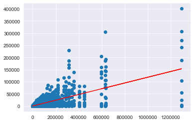

```python
# defining the feature and target columns
x = data_df['youth_pop_2019']
y = data_df['cases']

lin_reg = LinearRegression()
lin_reg.fit(x.values.reshape(-1,1),y)
pred = lin_reg.predict(x.values.reshape(-1,1))  # just making sure this doesn't cause any errors

r_val = lin_reg.score(x.values.reshape(-1,1),y)
print(r_val)

# plt.ylim(0, 50000)
plt.plot(x.values.reshape(-1,1),pred, c='r')

plt.scatter(data_df['youth_pop_2019'],y)
```

## Interpretation and Insight

Now that we've done some analysis on our data, it is time to draw meaningful conclusions from it.

In our case, it looks like there is indeed a relationship between the youth population (ages 15-24) and the number of COVID cases in a county. Whether or not this is a causal relationship is hard to tell without looking at other factors, but we have shown that there is at least a correlation relationship between the two.

Further analysis is necessary to determine the exact relationship. Some things to look into include collecting data from a few other sources (to fill in the gap from the data we had to discard), collecting data for other countries (to see if trends are similar), and employing more advanced machine learning techniques that take more factors into consideration.